# Forest Cover Type

Ayonija

# FOREST COVER TYPE DATA

To predict the forest cover type (the predominant kind of tree cover) from cartographic variables.  
The study area includes four wilderness areas located in the Roosevelt National Forest of northern Colorado. Each observation is a 30m x 30m patch. This project focuses to predict an integer classification for the forest cover type.

The seven types are: 1 - Spruce/Fir 2 - Lodgepole Pine 3 - Ponderosa Pine 4 - Cottonwood/Willow 5 - Aspen 6 - Douglas-fir 7 - Krummholz

While forests have great value to society by providing clean water, fresh air, carbon storage and timber, predicting the forest type will help us provide better solutions for environmental and economical growth of society. Abstracting data and observing it!! ====

```r
forest=read.csv("C:/Users/HP/Documents/lets start/SEM 5/MACHINE LEARNING/forest-cover-type-kernels-only/train.csv")
names(forest)
```

```
##  [1] "Id"
##  [2] "Cover_Type"
##  [3] "Elevation"
##  [4] "Aspect"
##  [5] "Slope"
##  [6] "Horizontal_Distance_To_Hydrology"
##  [7] "Vertical_Distance_To_Hydrology"
##  [8] "Horizontal_Distance_To_Roadways"
##  [9] "Hillshade_9am"
## [10] "Hillshade_Noon"
## [11] "Hillshade_3pm"
## [12] "Horizontal_Distance_To_Fire_Points"
## [13] "Wilderness_Area1"
## [14] "Wilderness_Area2"
## [15] "Wilderness_Area3"
```

[output cut: 41 more lines]

```r
dim(forest)
```

```
## [1] 15120    56
```

```r
class(forest)
```

```
## [1] "data.frame"
```

```r
summary(forest)
```

```
##        Id          Cover_Type   Elevation        Aspect
##  Min.   :    1   Min.   :1    Min.   :1863   Min.   :  0.0
##  1st Qu.: 3781   1st Qu.:2    1st Qu.:2376   1st Qu.: 65.0
##  Median : 7560   Median :4    Median :2752   Median :126.0
##  Mean   : 7560   Mean   :4    Mean   :2749   Mean   :156.7
##  3rd Qu.:11340   3rd Qu.:6    3rd Qu.:3104   3rd Qu.:261.0
##  Max.   :15120   Max.   :7    Max.   :3849   Max.   :360.0
##      Slope      Horizontal_Distance_To_Hydrology
##  Min.   : 0.0   Min.   :   0.0
##  1st Qu.:10.0   1st Qu.:  67.0
##  Median :15.0   Median : 180.0
##  Mean   :16.5   Mean   : 227.2
##  3rd Qu.:22.0   3rd Qu.: 330.0
##  Max.   :52.0   Max.   :1343.0
##  Vertical_Distance_To_Hydrology Horizontal_Distance_To_Roadways
##  Min.   :-146.00                Min.   :   0
##  1st Qu.:   5.00                1st Qu.: 764
##  Median :  32.00                Median :1316
##  Mean   :  51.08                Mean   :1714
##  3rd Qu.:  79.00                3rd Qu.:2270
##  Max.   : 554.00                Max.   :6890
##  Hillshade_9am   Hillshade_Noon Hillshade_3pm
##  Min.   :  0.0   Min.   : 99    Min.   :  0.0
##  1st Qu.:196.0   1st Qu.:207    1st Qu.:106.0
##  Median :220.0   Median :223    Median :138.0
##  Mean   :212.7   Mean   :219    Mean   :135.1
##  3rd Qu.:235.0   3rd Qu.:235    3rd Qu.:167.0
##  Max.   :254.0   Max.   :254    Max.   :248.0
##  Horizontal_Distance_To_Fire_Points Wilderness_Area1 Wilderness_Area2
##  Min.   :   0                       Min.   :0.0000   Min.   :0.000
##  1st Qu.: 730                       1st Qu.:0.0000   1st Qu.:0.000
##  Median :1256                       Median :0.0000   Median :0.000
##  Mean   :1511                       Mean   :0.2379   Mean   :0.033
##  3rd Qu.:1988                       3rd Qu.:0.0000   3rd Qu.:0.000
##  Max.   :6993                       Max.   :1.0000   Max.   :1.000
##  Wilderness_Area3 Wilderness_Area4   Soil_Type1        Soil_Type2
##  Min.   :0.0000   Min.   :0.0000   Min.   :0.00000   Min.   :0.0000
##  1st Qu.:0.0000   1st Qu.:0.0000   1st Qu.:0.00000   1st Qu.:0.0000
##  Median :0.0000   Median :0.0000   Median :0.00000   Median :0.0000
##  Mean   :0.4199   Mean   :0.3092   Mean   :0.02348   Mean   :0.0412
```

[output cut: 64 more lines]

```
##  Max.   :1.00000   Max.   :1.000000   Max.   :1.000000
##   Soil_Type36         Soil_Type37        Soil_Type38
##  Min.   :0.0000000   Min.   :0.000000   Min.   :0.00000
##  1st Qu.:0.0000000   1st Qu.:0.000000   1st Qu.:0.00000
##  Median :0.0000000   Median :0.000000   Median :0.00000
##  Mean   :0.0006614   Mean   :0.002249   Mean   :0.04815
##  3rd Qu.:0.0000000   3rd Qu.:0.000000   3rd Qu.:0.00000
##  Max.   :1.0000000   Max.   :1.000000   Max.   :1.00000
##   Soil_Type39       Soil_Type40
##  Min.   :0.00000   Min.   :0.00000
##  1st Qu.:0.00000   1st Qu.:0.00000
##  Median :0.00000   Median :0.00000
##  Mean   :0.04345   Mean   :0.03036
##  3rd Qu.:0.00000   3rd Qu.:0.00000
##  Max.   :1.00000   Max.   :1.00000
```

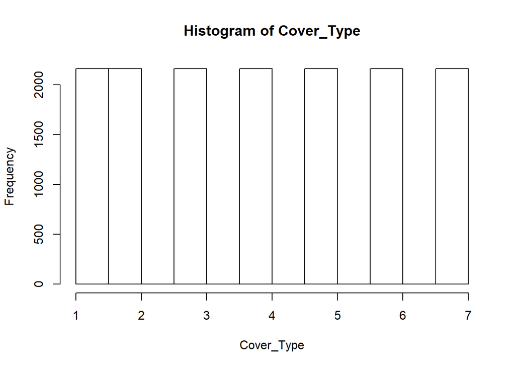

```r
attach(forest)
library(ISLR)
library(MASS)
hist(Cover_Type)
```

```r
#plot(Cover_Type~.,forest)
```

# Applying Multiple Linear Regression

```r
fit1=lm(Cover_Type~.,forest)
summary(fit1)
```

```
##
## Call:
## lm(formula = Cover_Type ~ ., data = forest)
##
## Residuals:
##     Min      1Q  Median      3Q     Max
## -6.1299 -1.0931  0.0045  1.0851  5.7893
##
## Coefficients: (4 not defined because of singularities)
##                                      Estimate Std. Error t value Pr(>|t|)
## (Intercept)                         5.501e+00  8.118e-01   6.777 1.27e-11
## Id                                 -1.981e-05  3.400e-06  -5.827 5.77e-09
## Elevation                          -3.835e-04  1.051e-04  -3.648 0.000265
## Aspect                              7.479e-04  1.597e-04   4.683 2.85e-06
## Slope                               9.522e-03  4.550e-03   2.093 0.036373
## Horizontal_Distance_To_Hydrology   -1.058e-03  9.379e-05 -11.280  < 2e-16
## Vertical_Distance_To_Hydrology      1.674e-03  3.076e-04   5.443 5.31e-08
## Horizontal_Distance_To_Roadways    -1.618e-04  1.372e-05 -11.793  < 2e-16
## Hillshade_9am                       2.066e-02  4.526e-03   4.564 5.05e-06
## Hillshade_Noon                     -1.601e-02  3.753e-03  -4.265 2.01e-05
## Hillshade_3pm                       1.338e-02  3.707e-03   3.608 0.000309
## Horizontal_Distance_To_Fire_Points  1.036e-04  1.506e-05   6.878 6.29e-12
## Wilderness_Area1                   -7.674e-01  8.273e-02  -9.276  < 2e-16
## Wilderness_Area2                   -4.271e-01  1.052e-01  -4.061 4.92e-05
## Wilderness_Area3                    4.994e-01  5.791e-02   8.624  < 2e-16
## Wilderness_Area4                           NA         NA      NA       NA
## Soil_Type1                         -3.230e+00  1.526e-01 -21.168  < 2e-16
## Soil_Type2                         -3.175e+00  1.306e-01 -24.309  < 2e-16
## Soil_Type3                         -3.603e+00  1.361e-01 -26.467  < 2e-16
## Soil_Type4                         -3.728e+00  1.265e-01 -29.477  < 2e-16
## Soil_Type5                         -2.859e+00  1.723e-01 -16.592  < 2e-16
## Soil_Type6                         -3.207e+00  1.300e-01 -24.664  < 2e-16
## Soil_Type7                                 NA         NA      NA       NA
## Soil_Type8                         -3.970e+00  1.549e+00  -2.562 0.010407
## Soil_Type9                         -4.515e+00  5.029e-01  -8.978  < 2e-16
## Soil_Type10                        -2.689e+00  1.178e-01 -22.827  < 2e-16
## Soil_Type11                        -3.326e+00  1.301e-01 -25.561  < 2e-16
## Soil_Type12                        -4.369e+00  1.486e-01 -29.401  < 2e-16
## Soil_Type13                        -2.976e+00  1.207e-01 -24.653  < 2e-16
## Soil_Type14                        -3.065e+00  1.731e-01 -17.706  < 2e-16
```

[output cut: 74 more lines]

```
## Soil_Type32                        ***
## Soil_Type33                        ***
## Soil_Type34                        ***
## Soil_Type35
## Soil_Type36
## Soil_Type37                        ***
## Soil_Type38                        *
## Soil_Type39                        ***
## Soil_Type40
## ---
## Signif. codes:  0 '***' 0.001 '**' 0.01 '*' 0.05 '.' 0.1 ' ' 1
##
## Residual standard error: 1.545 on 15068 degrees of freedom
## Multiple R-squared:  0.4054, Adjusted R-squared:  0.4034
## F-statistic: 201.5 on 51 and 15068 DF,  p-value: < 2.2e-16
```

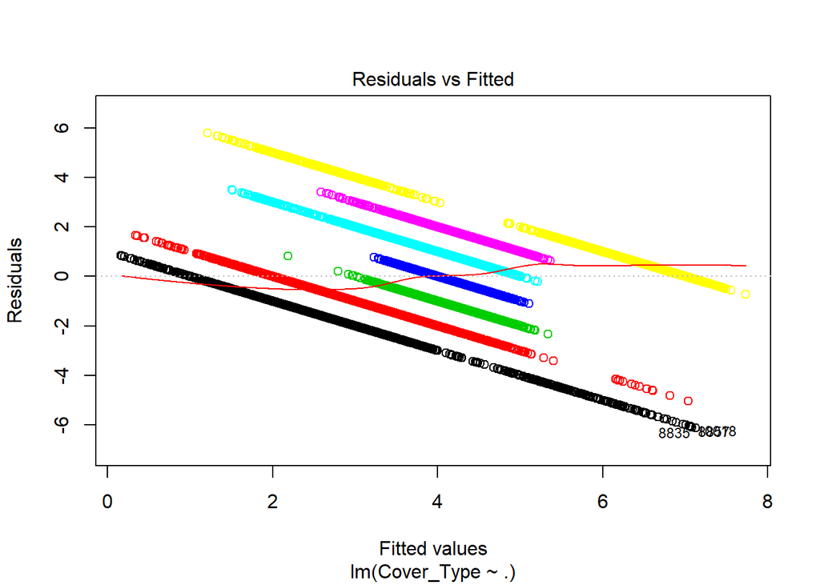

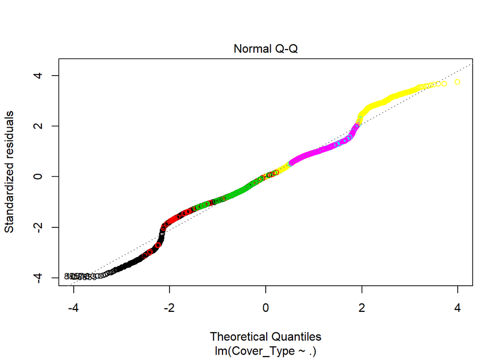

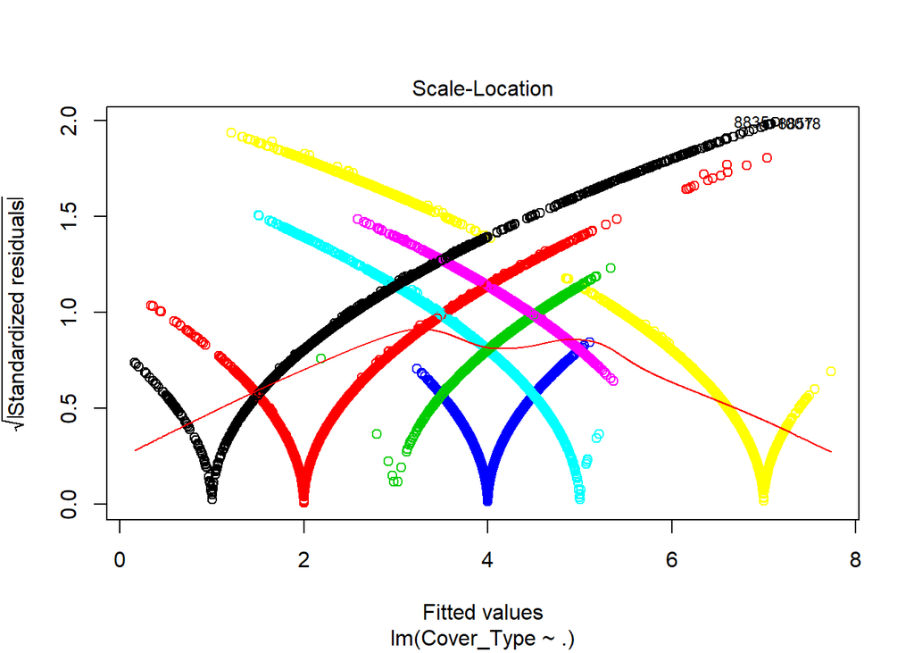

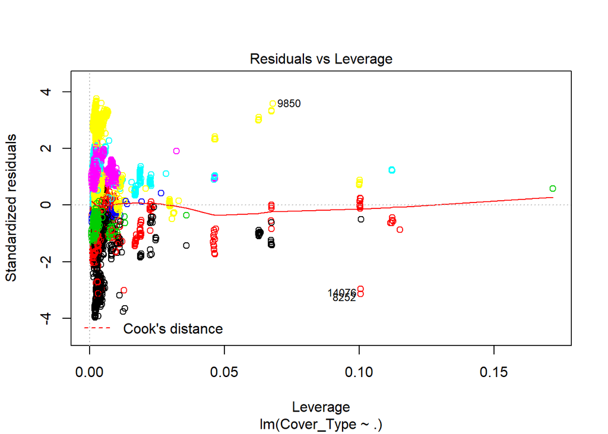

```r
plot(fit1,col=Cover_Type)
```

Multiple linear regression after excluding categories which are not affecting the model =====

```r
fit2=update(fit1,~.-Wilderness_Area4-Soil_Type7-Soil_Type15-Soil_Type35-Soil_Type36-Soil_Type40)
summary(fit2)
```

```
##
## Call:
## lm(formula = Cover_Type ~ Id + Elevation + Aspect + Slope + Horizontal_Distance_To_Hydrology +
##     Vertical_Distance_To_Hydrology + Horizontal_Distance_To_Roadways +
##     Hillshade_9am + Hillshade_Noon + Hillshade_3pm + Horizontal_Distance_To_Fire_Points +
##     Wilderness_Area1 + Wilderness_Area2 + Wilderness_Area3 +
##     Soil_Type1 + Soil_Type2 + Soil_Type3 + Soil_Type4 + Soil_Type5 +
##     Soil_Type6 + Soil_Type8 + Soil_Type9 + Soil_Type10 + Soil_Type11 +
##     Soil_Type12 + Soil_Type13 + Soil_Type14 + Soil_Type16 + Soil_Type17 +
##     Soil_Type18 + Soil_Type19 + Soil_Type20 + Soil_Type21 + Soil_Type22 +
##     Soil_Type23 + Soil_Type24 + Soil_Type25 + Soil_Type26 + Soil_Type27 +
##     Soil_Type28 + Soil_Type29 + Soil_Type30 + Soil_Type31 + Soil_Type32 +
##     Soil_Type33 + Soil_Type34 + Soil_Type37 + Soil_Type38 + Soil_Type39,
##     data = forest)
##
## Residuals:
##     Min      1Q  Median      3Q     Max
## -6.1325 -1.0930  0.0059  1.0844  5.7913
##
## Coefficients:
##                                      Estimate Std. Error t value Pr(>|t|)
## (Intercept)                         5.517e+00  8.111e-01   6.802 1.07e-11
## Id                                 -1.977e-05  3.400e-06  -5.815 6.19e-09
## Elevation                          -3.817e-04  1.051e-04  -3.632 0.000282
## Aspect                              7.485e-04  1.597e-04   4.688 2.79e-06
## Slope                               9.438e-03  4.548e-03   2.075 0.037981
## Horizontal_Distance_To_Hydrology   -1.067e-03  9.328e-05 -11.436  < 2e-16
## Vertical_Distance_To_Hydrology      1.681e-03  3.065e-04   5.483 4.26e-08
## Horizontal_Distance_To_Roadways    -1.620e-04  1.372e-05 -11.810  < 2e-16
## Hillshade_9am                       2.063e-02  4.526e-03   4.558 5.21e-06
## Hillshade_Noon                     -1.599e-02  3.752e-03  -4.263 2.03e-05
## Hillshade_3pm                       1.335e-02  3.707e-03   3.602 0.000316
## Horizontal_Distance_To_Fire_Points  1.035e-04  1.504e-05   6.884 6.06e-12
## Wilderness_Area1                   -7.666e-01  8.272e-02  -9.267  < 2e-16
## Wilderness_Area2                   -4.298e-01  1.047e-01  -4.103 4.10e-05
## Wilderness_Area3                    4.993e-01  5.791e-02   8.622  < 2e-16
## Soil_Type1                         -3.241e+00  1.472e-01 -22.024  < 2e-16
## Soil_Type2                         -3.185e+00  1.245e-01 -25.588  < 2e-16
## Soil_Type3                         -3.613e+00  1.301e-01 -27.776  < 2e-16
## Soil_Type4                         -3.738e+00  1.199e-01 -31.177  < 2e-16
```

[output cut: 73 more lines]

```
## Soil_Type29                        ***
## Soil_Type30                        ***
## Soil_Type31                        ***
## Soil_Type32                        ***
## Soil_Type33                        ***
## Soil_Type34                        ***
## Soil_Type37                        ***
## Soil_Type38                        *
## Soil_Type39                        ***
## ---
## Signif. codes:  0 '***' 0.001 '**' 0.01 '*' 0.05 '.' 0.1 ' ' 1
##
## Residual standard error: 1.545 on 15070 degrees of freedom
## Multiple R-squared:  0.4054, Adjusted R-squared:  0.4035
## F-statistic: 209.7 on 49 and 15070 DF,  p-value: < 2.2e-16
```

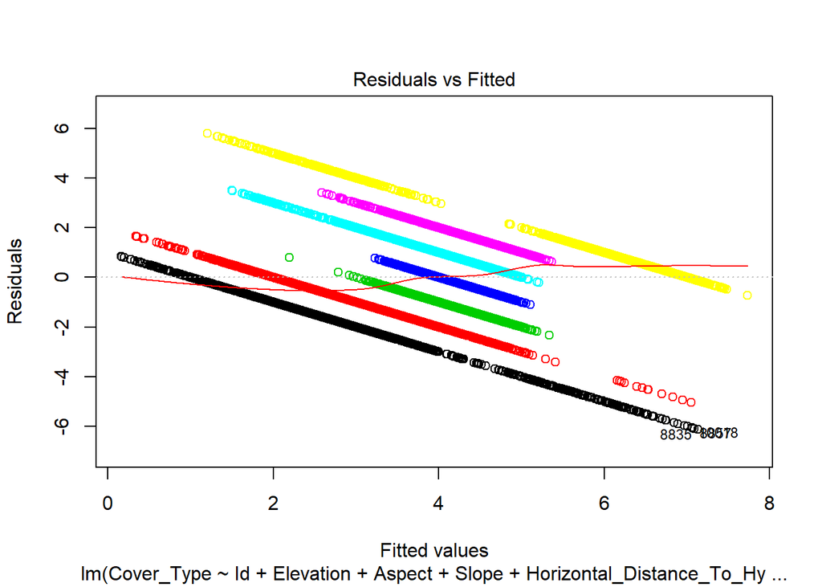

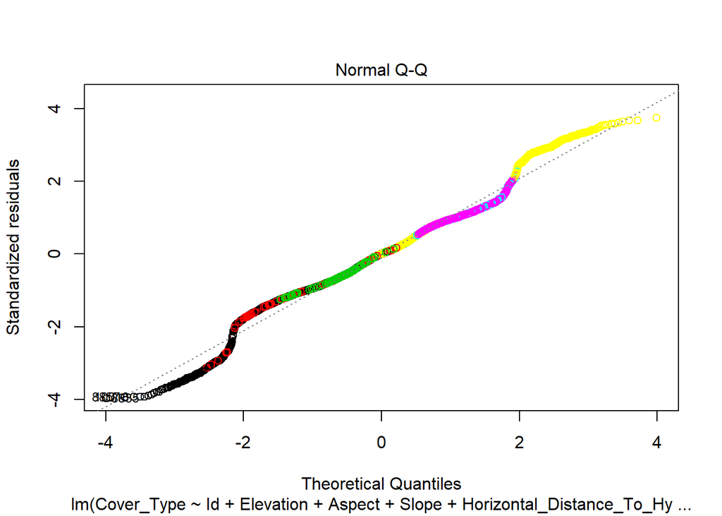

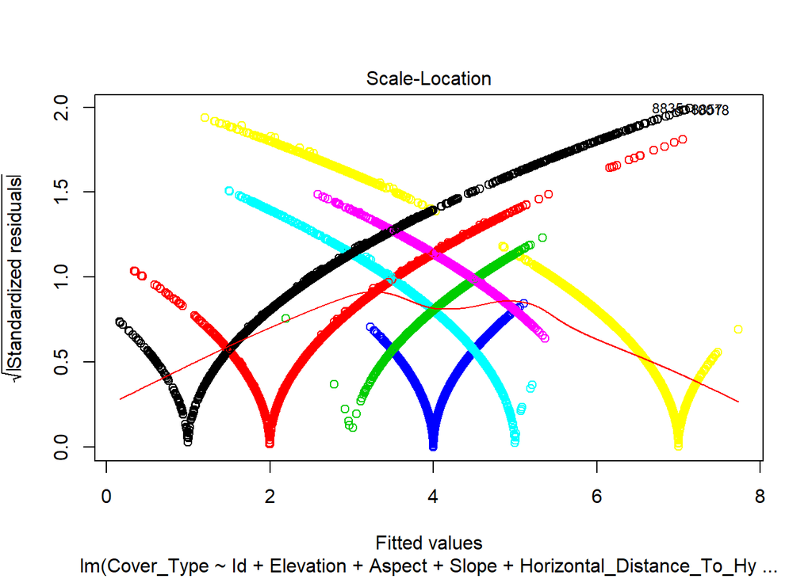

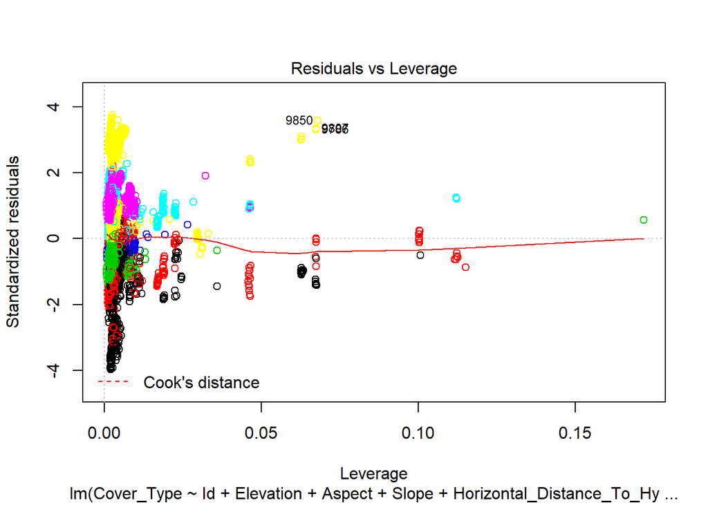

```r
plot(fit2,col=Cover_Type)
```

Applying LDA ===

```r
forest=na.omit(forest)
lda.fit=lda(Cover_Type~Elevation+Aspect+Slope+Horizontal_Distance_To_Hydrology+Horizontal_Distance_To_Roadways+Vertical_Distance_To_Hydrology+Hillshade_9am+Hillshade_Noon+Hillshade_3pm+Horizontal_Distance_To_Fire_Points+Wilderness_Area1+Soil_Type1,data=forest,subset = Id<7560)
lda.fit
```

```
## Call:
## lda(Cover_Type ~ Elevation + Aspect + Slope + Horizontal_Distance_To_Hydrology +
##     Horizontal_Distance_To_Roadways + Vertical_Distance_To_Hydrology +
##     Hillshade_9am + Hillshade_Noon + Hillshade_3pm + Horizontal_Distance_To_Fire_Points +
##     Wilderness_Area1 + Soil_Type1, data = forest, subset = Id <
##     7560)
##
## Prior probabilities of groups:
##          1          2          3          4          5          6
## 0.10464347 0.15160736 0.14856462 0.21431406 0.16906998 0.15134277
##          7
## 0.06045773
##
## Group means:
##   Elevation   Aspect    Slope Horizontal_Distance_To_Hydrology
## 1  3095.315 144.6271 12.42225                         249.6018
## 2  2891.533 151.0079 12.43979                         267.0611
## 3  2322.868 181.3375 21.49510                         209.0018
## 4  2224.977 138.6704 18.48642                         105.2025
## 5  2783.534 134.0626 17.05790                         174.2801
## 6  2373.412 198.3383 20.25874                         177.8234
## 7  3304.639 134.8009 12.90153                         230.3501
##   Horizontal_Distance_To_Roadways Vertical_Distance_To_Hydrology
## 1                       3240.4842                       34.65234
## 2                       2652.3447                       42.35951
## 3                        758.0267                       69.91006
## 4                        911.0259                       40.44444
## 5                       1180.4961                       41.19249
## 6                        909.1477                       54.49301
## 7                       2878.7046                       35.71554
##   Hillshade_9am Hillshade_Noon Hillshade_3pm
## 1      214.3059       222.2478      140.3515
## 2      214.6274       224.6667      142.5131
## 3      193.5859       210.3072      144.1612
## 4      227.5562       217.0667      112.4611
## 5      223.0595       217.0806      120.2770
## 6      187.1049       208.3208      152.5900
## 7      220.2976       221.5011      132.2604
##   Horizontal_Distance_To_Fire_Points Wilderness_Area1 Soil_Type1
## 1                          2362.7724        0.8445006 0.00000000
```

[output cut: 36 more lines]

```
## Aspect                             -0.0039063127 -0.0006195341
## Slope                              -0.0818993764  0.0045181107
## Horizontal_Distance_To_Hydrology    0.0012502357 -0.0018717829
## Horizontal_Distance_To_Roadways     0.0001028987  0.0002757561
## Vertical_Distance_To_Hydrology      0.0073278206 -0.0022590725
## Hillshade_9am                      -0.1746437736 -0.0268850996
## Hillshade_Noon                      0.1659882691  0.0085915368
## Hillshade_3pm                      -0.1420489266 -0.0168447796
## Horizontal_Distance_To_Fire_Points -0.0002829376 -0.0007171466
## Wilderness_Area1                    0.1257930851  1.8482545889
## Soil_Type1                          0.9091691204 -0.1282839045
##
## Proportion of trace:
##    LD1    LD2    LD3    LD4    LD5    LD6
## 0.9105 0.0458 0.0293 0.0105 0.0026 0.0012
```

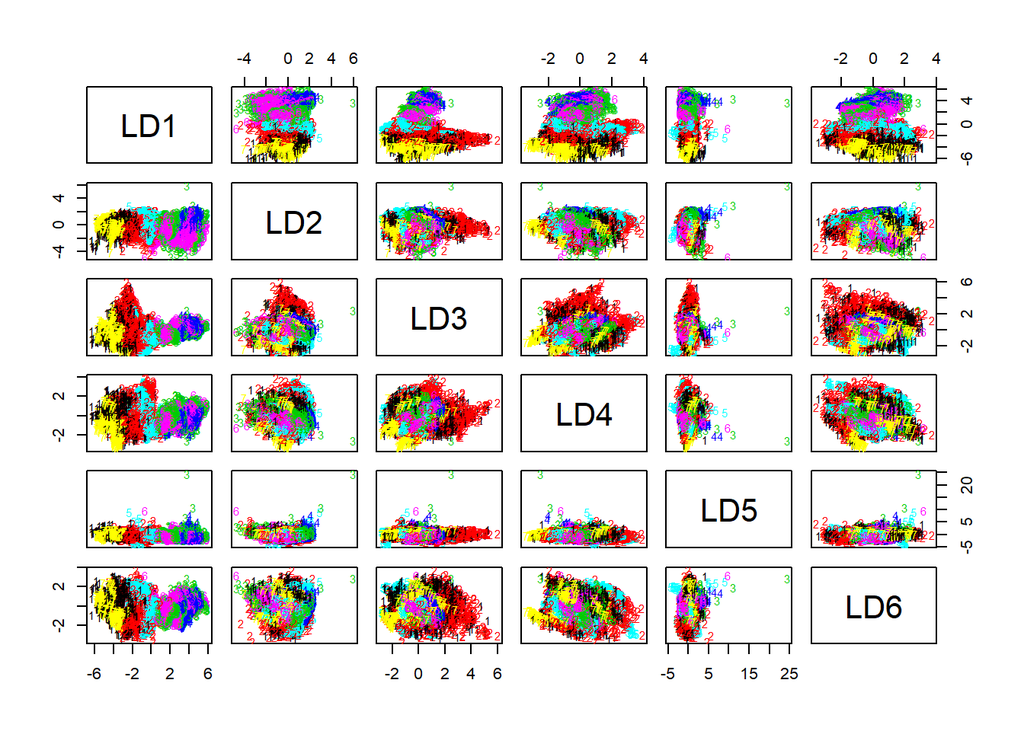

```r
plot(lda.fit,col=Cover_Type)
```

```r
forest.7560=subset(forest,Id>7560)
lda.pred=predict(lda.fit,forest.7560)
class(lda.pred)
```

```
## [1] "list"
```

```r
data.frame(lda.pred)[1:5,]
```

```
##      class  posterior.1  posterior.2 posterior.3 posterior.4 posterior.5
## 7561     5 4.340090e-03 0.2654242157  0.05053955  0.01441893  0.54112814
## 7562     5 1.758588e-03 0.1261579840  0.05269009  0.03054900  0.61448786
## 7563     5 1.684363e-03 0.1325821662  0.05529380  0.03635122  0.59767976
## 7564     6 3.909149e-06 0.0014861021  0.22371027  0.22526827  0.04200848
## 7565     4 6.637587e-07 0.0005569471  0.13984351  0.67481867  0.03226464
##      posterior.6  posterior.7      x.LD1     x.LD2       x.LD3      x.LD4
## 7561   0.1241241 2.494883e-05 -0.3137116 0.2798418  0.37765973 -1.3384161
## 7562   0.1743433 1.318104e-05 -0.1279826 0.5305871 -0.02094790 -1.5326177
## 7563   0.1763975 1.117752e-05 -0.1024683 0.5943937  0.05746035 -1.4991761
## 7564   0.5075230 6.200440e-09  1.0808596 0.3412082 -0.40519206 -1.1783863
## 7565   0.1525156 6.750280e-10  1.3494574 1.4363574 -0.46948940 -0.7103453
##            x.LD5      x.LD6
## 7561  0.09627281 -0.7397596
## 7562 -0.66152221 -0.6088038
## 7563 -0.66774782 -0.6646789
## 7564 -0.88996480  0.0938163
## 7565 -0.49693314 -0.2330391
```

```r
table(lda.pred$class,forest.7560$Cover_Type)
```

```
##
##        1    2    3    4    5    6    7
##   1  325  100    0    0    2    0  127
##   2  193  356   21    0  152   20   33
##   3    0    6  278   18    0   95    0
##   4    1    4  318  486    6  186    0
##   5  247  369  147    0  658  112   14
##   6    3   42  273   36   64  602    0
##   7  600  137    0    0    0    0 1529
```

```r
mean(lda.pred$class==forest.7560$Cover_Type)
```

```
## [1] 0.5600529
```